# Altermap 2026 : COMMENT VOYEZ-VOUS LE MONDE ?

Analyse des réponses de 61 étudiants français et 87 étudiants sénégalais de licence 3 au questionnaire pilote administré en mars-avril 2026

Auteur·rice

Labaly Touré, Claude Grasland

Date de publication

2026-05-08

# A. QUELQUES QUESTIONS SUR VOUS

La première partie du questionnaire apportait des données de cadrage sur les individus (âge, sexe), sur la perception du niveau de revenu de la famille et les études des parents, ainsi que l’expérience international de la mobilité.

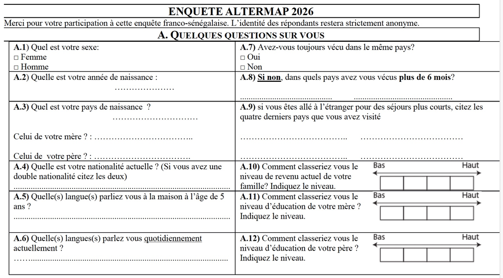

Altermap 2026 - Questionnaire - Partie 1

**Télécharger le jeu de données issues de Kobo Toolbox**

- [Données d’enquête issus de kobo au format label .xlsx](https://github.com/worldregio/altermap/raw/refs/heads/main/data/axe1/ALTERMAP_2026_Vision_du_Monde_SMA_labels_V3.xlsx)
- [Données d’enquêteissus de kobo au format code .xlsx](https://github.com/worldregio/altermap/raw/refs/heads/maindata/axe1/ALTERMAP_2026_Vision_du_Monde_SMA_codes_V3.xlsx)

On commence par charger les questionnaires issus de Kobo Toolbox en format “label” (texte complet) ou en format “codes” (codes) pour constituer notre tableau de données. Selon le cas on utilisera l’un ou l’autre tableau pour nos analyses. On va ensuite construire à partir de ces deux fichiers notre tableau de donnée de référence

On se propose dans cette première analyse d’étudier les réponses des étudiants de licence SIG de l’Université de USSEIN à Kaolack (Sénégal)

## A.1 Echantillonage

### Sexe

Effectifs par sexe

|  | Un homme | Une femme | Sum |
| --- | --- | --- | --- |
| Paris | 31 | 30 | 61 |
| Kaolack | 49 | 38 | 87 |
| Sum | 80 | 68 | 148 |

```
          Un homme Une femme Total
  Paris    50.8     49.2     100.0
  Kaolack  56.3     43.7     100.0
  All      54.1     45.9     100.0
```

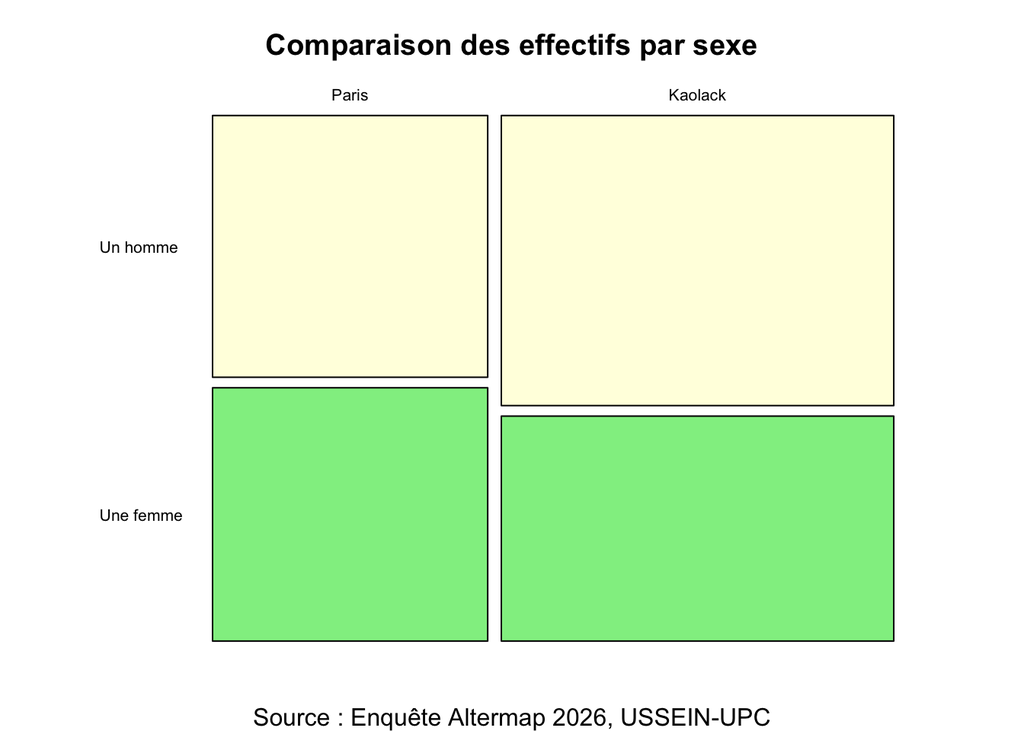

```
    Pearson's Chi-squared test with Yates' continuity correction

data:  tab
X-squared = 0.24363, df = 1, p-value = 0.6216
```

### Âge

```
   Min. 1st Qu.  Median    Mean 3rd Qu.    Max.    NA's
  20.00   21.00   23.00   23.23   25.00   29.00       3
```

Effectifs par âge

[output not shown]

```
          20-21 ans 22-25 ans 26-28 ans Total
  Paris    72.1      23.0       4.9     100.0
  Kaolack   3.6      70.2      26.2     100.0
  All      32.4      50.3      17.2     100.0
```

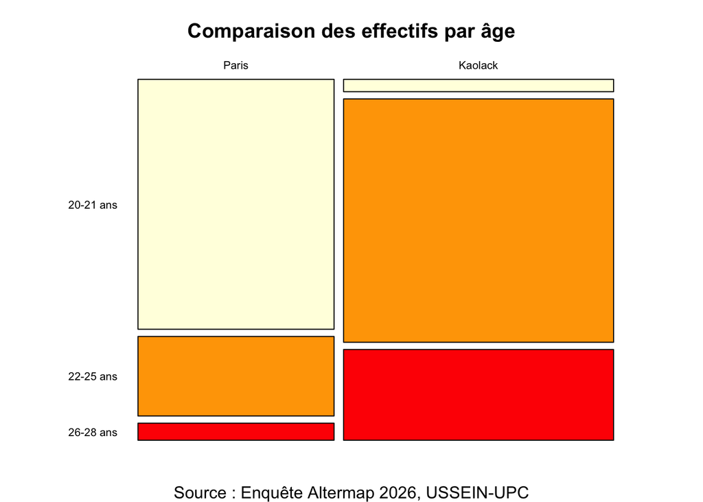

```
    Pearson's Chi-squared test

data:  tab
X-squared = 76.215, df = 2, p-value < 2.2e-16
```

## A.2 Variables de cadrage

### Niveau économique familial

L’autoévaluation du niveau économique a été faite sur une échelle graphique comportant quatre cases. Mais les étudiants ont souvent coché des cases situées sur les lignes séparant les cases, ce qui aboutissait à 8 ou 9 réponses possibles que l’on a ramené à 5 classes

Perception du niveau de richesse familial

|  | 1. très bas | 2. bas | 3. moyen | 4. haut | 5. très haut | Sum |
| --- | --- | --- | --- | --- | --- | --- |
| Paris | 1 | 17 | 8 | 25 | 10 | 61 |
| Kaolack | 11 | 19 | 25 | 21 | 11 | 87 |
| Sum | 12 | 36 | 33 | 46 | 21 | 148 |

```
          1. très bas 2. bas 3. moyen 4. haut 5. très haut Total
  Paris     1.6        27.9   13.1     41.0    16.4        100.0
  Kaolack  12.6        21.8   28.7     24.1    12.6        100.0
  All       8.1        24.3   22.3     31.1    14.2        100.0
```

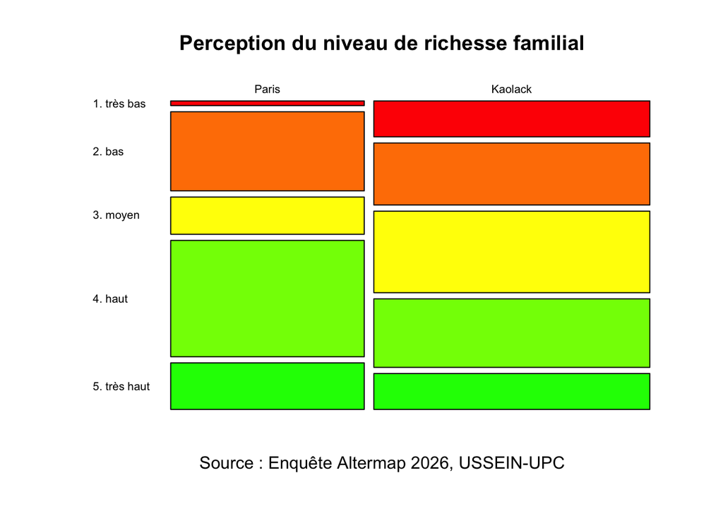

```
    Pearson's Chi-squared test with simulated p-value (based on 2000
    replicates)

data:  tab
X-squared = 13.445, df = NA, p-value = 0.008496
```

### Niveau d’éducation des parents

On analyse ensuite le niveau d’éducation des parents :

Perception du niveau d’éducation de la mère

|  | 1. très bas | 2. bas | 3. moyen | 4. haut | 5. très haut | Sum |
| --- | --- | --- | --- | --- | --- | --- |
| Paris | 1 | 17 | 5 | 22 | 16 | 61 |
| Kaolack | 15 | 16 | 15 | 12 | 29 | 87 |
| Sum | 16 | 33 | 20 | 34 | 45 | 148 |

```
          1. très bas 2. bas 3. moyen 4. haut 5. très haut Total
  Paris     1.6        27.9    8.2     36.1    26.2        100.0
  Kaolack  17.2        18.4   17.2     13.8    33.3        100.0
  All      10.8        22.3   13.5     23.0    30.4        100.0
```

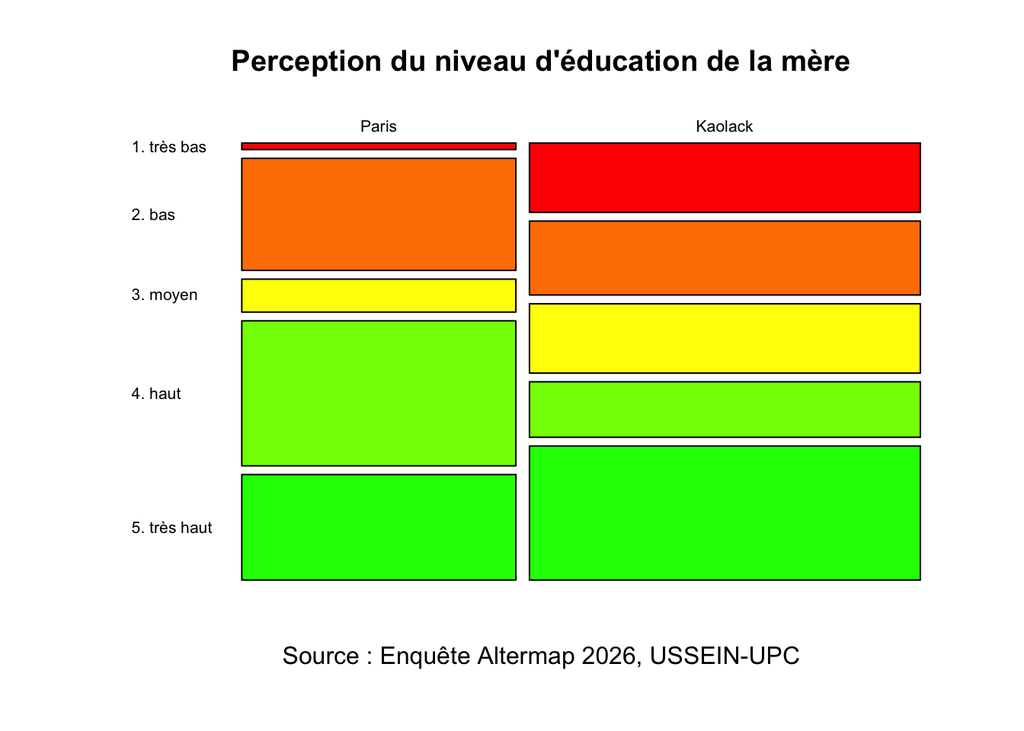

```
    Pearson's Chi-squared test with simulated p-value (based on 2000
    replicates)

data:  tab
X-squared = 20.028, df = NA, p-value = 0.0004998
```

Perception du niveau d’éducation du père

|  | 1. très bas | 2. bas | 3. moyen | 4. haut | 5. très haut | Sum |
| --- | --- | --- | --- | --- | --- | --- |
| Paris | 6 | 17 | 4 | 19 | 15 | 61 |
| Kaolack | 9 | 8 | 15 | 14 | 41 | 87 |
| Sum | 15 | 25 | 19 | 33 | 56 | 148 |

```
          1. très bas 2. bas 3. moyen 4. haut 5. très haut Total
  Paris     9.8        27.9    6.6     31.1    24.6        100.0
  Kaolack  10.3         9.2   17.2     16.1    47.1        100.0
  All      10.1        16.9   12.8     22.3    37.8        100.0
```

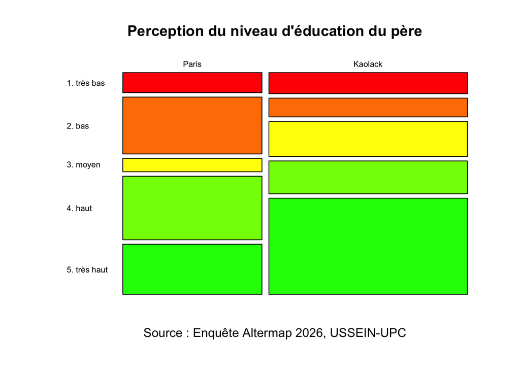

```
    Pearson's Chi-squared test with simulated p-value (based on 2000
    replicates)

data:  tab
X-squared = 19.058, df = NA, p-value = 0.0004998
```

## A.3 Expérience internationale

### Séjours de plus de 6 mois

Expérience internationale

|  | Oui | Non | Sum |
| --- | --- | --- | --- |
| Paris | 14 | 47 | 61 |
| Kaolack | 5 | 78 | 83 |
| Sum | 19 | 125 | 144 |

```
          Oui   Non   Total
  Paris    23.0  77.0 100.0
  Kaolack   6.0  94.0 100.0
  All      13.2  86.8 100.0
```

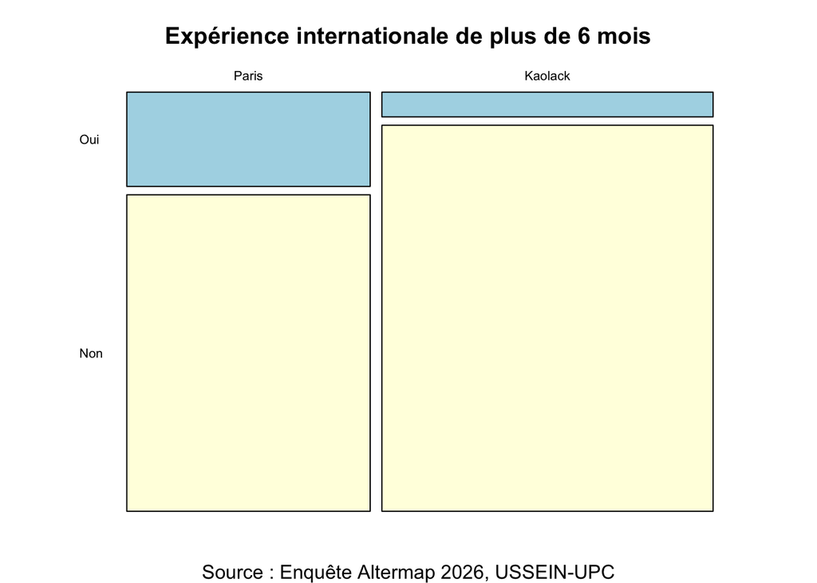

```
    Pearson's Chi-squared test with Yates' continuity correction

data:  tab
X-squared = 7.3796, df = 1, p-value = 0.006597
```

Très peu d’étudiants interrogés ont vécu à l’étranger plus de 6 mois.

### Mobilités de courte durée

On examine le nombre de pays visités quels que soit la durée du séjour, le maximum de réponse étant limité à 4.

Derniers pays visités (maximum 4)

|  | 0 | 1 | 2 | 3 | 4 | Sum |
| --- | --- | --- | --- | --- | --- | --- |
| Paris | 2 | 5 | 5 | 5 | 44 | 61 |
| Kaolack | 79 | 4 | 1 | 2 | 1 | 87 |
| Sum | 81 | 9 | 6 | 7 | 45 | 148 |

```
          0     1     2     3     4     Total
  Paris     3.3   8.2   8.2   8.2  72.1 100.0
  Kaolack  90.8   4.6   1.1   2.3   1.1 100.0
  All      54.7   6.1   4.1   4.7  30.4 100.0
```

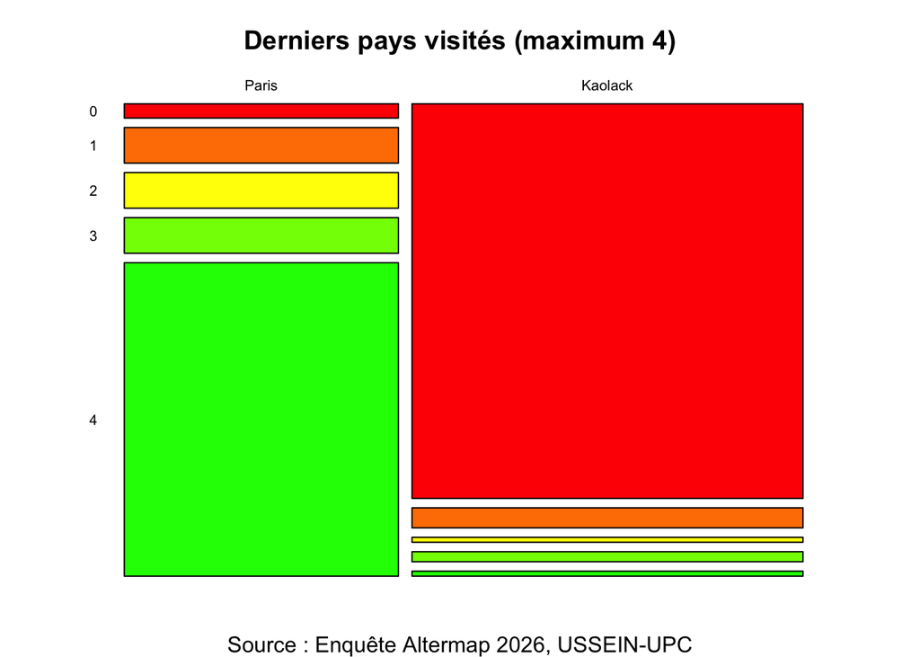

```
    Pearson's Chi-squared test with simulated p-value (based on 2000
    replicates)

data:  tab
X-squared = 117.41, df = NA, p-value = 0.0004998
```

La plupart des étudiants interrogés n’ont cité aucun pays étranger, même pour des visites de courte durée…

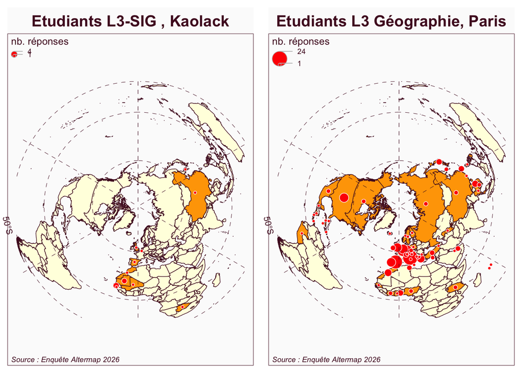

# B. VOTRE VISION DU MONDE

La seconde partie du questionnaire visait à analyser certains éléments de la vision du Monde des étudiants en utilisant trois entrées différentes : les échelles d’appartenance, les pays attractifs et répulsifs, les mots associés à certains espaces.

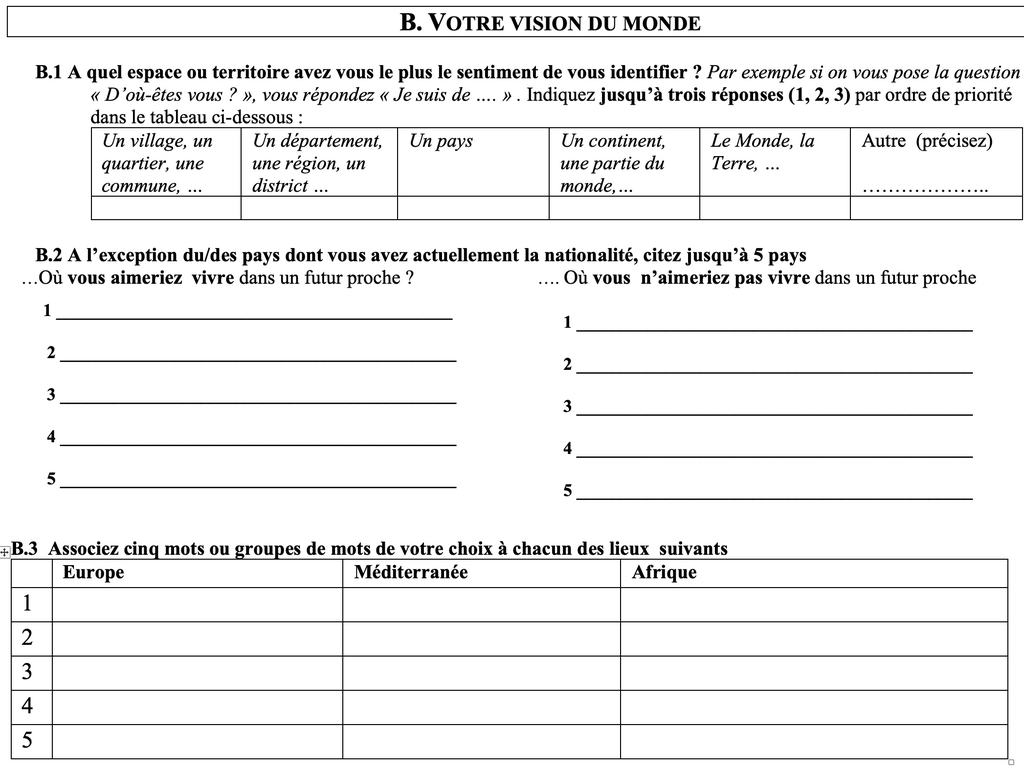

Altermap 2026 - Questionnaire - Partie B

## B.1 Echelles d’appartenance

La questions n’a sans doute pas été formulée de façon satisfaisante car beaucoup d’étudiants ont répondu d’une façon différente de celle qui avait été anticipée par les enquêteurs.

On attendait en effet des étudiants qu’ils choisissent parmi les niveaux proposés les trois échelle territoriale auxquelles ils s’identifient le plus en les ordonnant. Soit une réponse du type suivant :

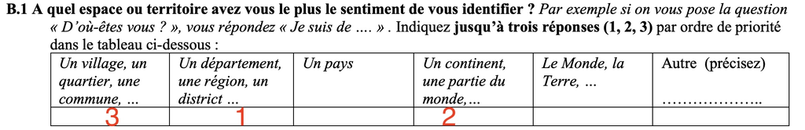

Altermap 2026 - Question B1 - Réponse attendue

Mais certains étudiant ont compris la question différemment et ont plutôt indiqué les lieux correspondant à leurs échelles d’appartenance territoriale, sans les hiérarchiser, aboutissant à des réponses du type suivant :

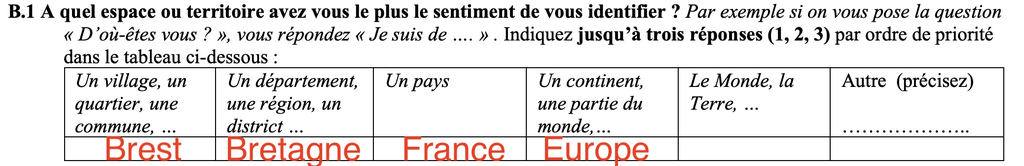

Altermap 2026 - Question B1 - Réponse inattendue

Il est donc clair que la question doit être construite différemment dans les enquêtes futures et relève peut-être d’ailleurs plus d’un entretiens qualitatif où l’on poserait la question *“D’où êtes-vous ?”* sans préjuger du résultat mais en relançant la personne interrogée pour détecter l’existence de niveaux multiples. Il n’est d’ailleurs pas certain que l’idée d’ordonner les échelles soit pertinente. La réponse à la question peut en effet varier selon le contexte où elle est posée. Un sénégalais interrogé sur ses orignes dans un pays très éloigné pourra répondre qu’il vient du Sénégal ou d’Afrique. Le même individu interrogé par un habitant de son pays répondra plutôt qu’il vient de Casmance ou de Saint-Louis …

Peut-on néanmoins tirer quelques enseignements des réponses obtenues ?

### Echelle principale

Si on se limite aux étudiants s qui ont fourni un classement des échelles, on peut construire un tableau donnant l’échelle principale d’appartenance i.e. celle qui a été classée en première place :

```
[1] "N1" "N2" "N3" "N4" "X"
```

Echelle principale d’appartenance

|  | Local | Infranational | National | Supranational | Autre | Sum |
| --- | --- | --- | --- | --- | --- | --- |
| Paris | 17 | 18 | 11 | 0 | 1 | 47 |
| Kaolack | 63 | 11 | 7 | 3 | 0 | 84 |
| Sum | 80 | 29 | 18 | 3 | 1 | 131 |

```
          Local Infranational National Supranational Autre Total
  Paris    36.2  38.3          23.4      0.0           2.1 100.0
  Kaolack  75.0  13.1           8.3      3.6           0.0 100.0
  All      61.1  22.1          13.7      2.3           0.8 100.0
```

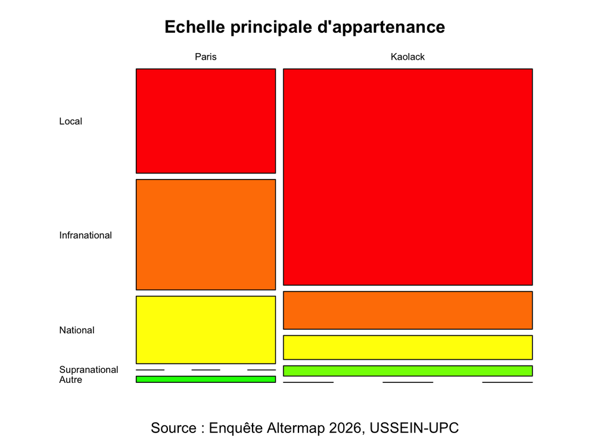

```
    Pearson's Chi-squared test with simulated p-value (based on 2000
    replicates)

data:  tab
X-squared = 24.535, df = NA, p-value = 0.0004998
```

Ce résultat confirme la prédominance des échelles locales et infranationales …

## B.2 Pays attractifs et répulsifs

Une manière efficace de mettre à jour les représentations du Monde des étudiants a consisté à leur demander les pays où ils souhaiteraient vivre ou ne pas vivre dans un futur proche. Cela suppose une petite préparation des données pour créer un tableau ou chaque ligne correspond à une réponse sur les pays attractifs ou répulsifs. En d’autres termes les réponses de chaque étudiant correspondront à 10 lignes, 5 pour les pays cités positivement et 5 pour les pays cités négativement.On accompagnera ces réponses des informations que l’on juge utile sur les étudiants afin de pouvoir ensuite faire des regroupements.

| id | loc | sex | age | age3 | mig | opi | rnk | nom |
| --- | --- | --- | --- | --- | --- | --- | --- | --- |
| SIG-L2 74 | Kaolack | Un homme | 25 | 22-25 ans | Non | neg | 1 | France |
| SIG-L2 74 | Kaolack | Un homme | 25 | 22-25 ans | Non | neg | 2 | Italy |
| SIG-L2 74 | Kaolack | Un homme | 25 | 22-25 ans | Non | neg | 3 | Mali |
| SIG-L2 74 | Kaolack | Un homme | 25 | 22-25 ans | Non | neg | 4 | Gambia |
| SIG-L2 74 | Kaolack | Un homme | 25 | 22-25 ans | Non | neg | 5 | Australia |
| SIG-L2 74 | Kaolack | Un homme | 25 | 22-25 ans | Non | pos | 1 | China |
| SIG-L2 74 | Kaolack | Un homme | 25 | 22-25 ans | Non | pos | 2 | Canada |
| SIG-L2 74 | Kaolack | Un homme | 25 | 22-25 ans | Non | pos | 3 | South Africa |
| SIG-L2 74 | Kaolack | Un homme | 25 | 22-25 ans | Non | pos | 4 | Japan |
| SIG-L2 74 | Kaolack | Un homme | 25 | 22-25 ans | Non | pos | 5 | North Korea |

-**Commentaire :** L’étudiant SIG-L2 74 est un homme de 25 ans, qui estime sont revenu familialmoyen et n’a effectué aucune mobilité. Il ne souhaiterait pas vivre en France, Italie, Mali, Gambie ou Australie. Il aimerait bien vivre en Chine, au Canada, en Afrique du Sud, au Japon ou en Corée du Nord.

### Pays attractifs

Si on ne tient pas compte du rang des pays cités positivement, on peut établir un tableau de fréquence indiquant le nombre de fois ou un pays a été cité positivement par l’un des étudiants de chacun de nos deux échantillon. On calcule ensuite pour chaque échantillon le pourcentage des étudiants qui ont cité le pays en question ce qui facilite la comparaison puisque les deux échantillons sont de tailles différentes.

| rang | Kaolack | nb. réponses | % | Paris | nb. réponses | % |
| --- | --- | --- | --- | --- | --- | --- |
| 1 | Canada | 64 | 73.6 | Italy | 34 | 55.7 |
| 2 | France | 46 | 52.9 | Spain | 24 | 39.3 |
| 3 | Spain | 32 | 36.8 | Canada | 17 | 27.9 |
| 4 | U.S.A. | 26 | 29.9 | Japan | 16 | 26.2 |
| 5 | Germany | 24 | 27.6 | Switzerland | 14 | 23.0 |
| 6 | China | 20 | 23.0 | U.K | 14 | 23.0 |
| 8 | U.K | 17 | 19.5 | Germany | 10 | 16.4 |
| 8 | Italy | 17 | 19.5 | China | 9 | 14.8 |
| 9 | Morocco | 14 | 16.1 | U.S.A. | 9 | 14.8 |
| 10 | Switzerland | 13 | 14.9 | Brazil | 8 | 13.1 |
| 10 | Japan | 13 | 14.9 | Norway | 7 | 11.5 |
| 12 | Belgium | 12 | 13.8 | Belgium | 5 | 8.2 |
| 13 | South Africa | 11 | 12.6 | Netherlands | 5 | 8.2 |
| 14 | Saudi Arabia | 8 | 9.2 | Portugal | 5 | 8.2 |
| 15 | Luxembourg | 7 | 8.0 | Singapore | 5 | 8.2 |
| 17 | Brazil | 6 | 6.9 | Thailand | 5 | 8.2 |
| 17 | Russia | 6 | 6.9 | France | 4 | 6.6 |
| 17 | Turkey | 6 | 6.9 | Republic of Korea | 4 | 6.6 |
| 20 | Côte d’Ivoire | 5 | 5.7 | Vietnam | 4 | 6.6 |
| 20 | Senegal | 5 | 5.7 | Argentina | 3 | 4.9 |

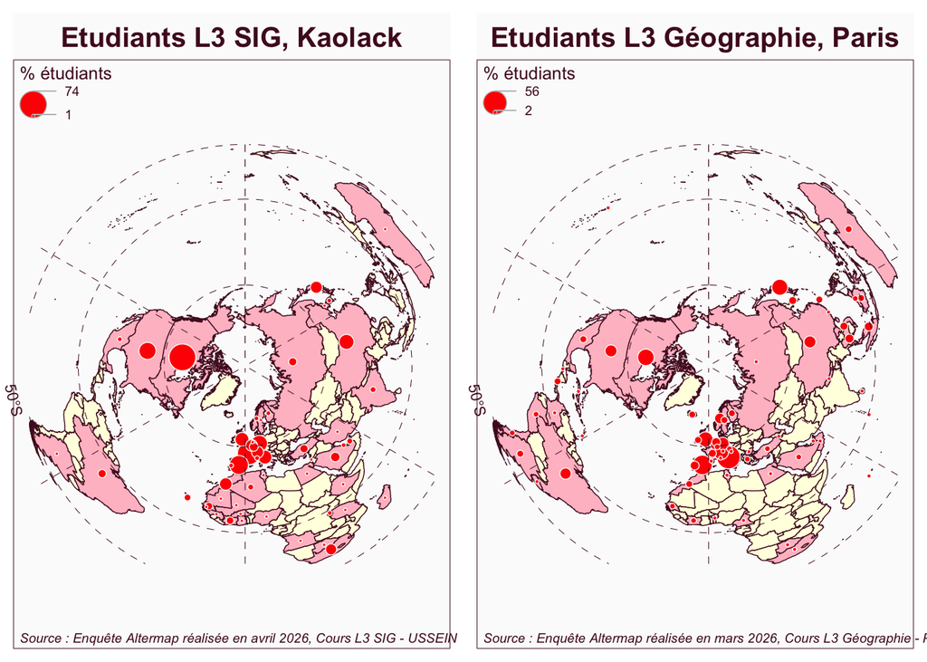

### Pays répulsifs

| rang | Kaolack | nb. réponses | % | Paris | nb. réponses | % |
| --- | --- | --- | --- | --- | --- | --- |
| 1 | Israel | 33 | 37.9 | Israel | 28 | 45.9 |
| 2 | Iran | 23 | 26.4 | Russia | 26 | 42.6 |
| 3 | Morocco | 21 | 24.1 | U.S.A. | 25 | 41.0 |
| 4 | France | 16 | 18.4 | Afghanistan | 21 | 34.4 |
| 6 | Italy | 11 | 12.6 | Iran | 21 | 34.4 |
| 6 | Mexico | 11 | 12.6 | North Korea | 13 | 21.3 |
| 8 | Libyan Arab Jamahiriya | 10 | 11.5 | Emirates | 12 | 19.7 |
| 8 | Mali | 10 | 11.5 | India | 12 | 19.7 |
| 8 | Gaza Strip | 10 | 11.5 | China | 9 | 14.8 |
| 8 | Russia | 10 | 11.5 | Qatar | 8 | 13.1 |
| 12 | Guinea | 9 | 10.3 | Sudan | 8 | 13.1 |
| 12 | Ukraine | 9 | 10.3 | Gaza Strip | 7 | 11.5 |
| 12 | U.S.A. | 9 | 10.3 | U.K | 6 | 9.8 |
| 15 | Afghanistan | 8 | 9.2 | Iraq | 6 | 9.8 |
| 15 | Côte d’Ivoire | 8 | 9.2 | Nigeria | 5 | 8.2 |
| 15 | Algeria | 8 | 9.2 | Saudi Arabia | 5 | 8.2 |
| 19 | Colombia | 7 | 8.0 | Syrian Arab Republic | 5 | 8.2 |
| 19 | India | 7 | 8.0 | Ukraine | 5 | 8.2 |
| 19 | Iraq | 7 | 8.0 | Australia | 3 | 4.9 |
| 19 | Nigeria | 7 | 8.0 | Democratic Republic of the Congo | 3 | 4.9 |

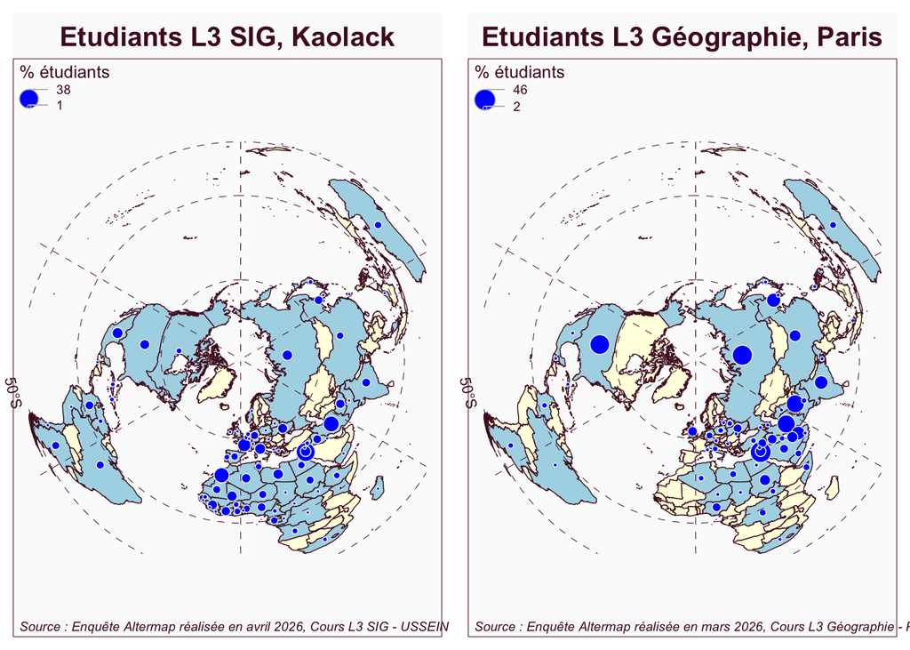

### Synthèse

Ce que montrent bien les analyses précédentes est le fait que l’appréciation que les étudiants donnent d’un pays doit être envisagé selon deux dimensions complémentaires, la saillance et l’opinion

- **la saillance** (en anglais *salience*) est le fait qu’un pays se présente à l’esprit dun étudiant lorsqu’on lui demande de porter un jugement. Peu importe que le jugement soit positif ou négatif, si un pays est cité par l’étudiant c’est qu’il possède des informations sur lui, qu’il en a reçu et à choisi de les retenir. Bref, la saillance manifeste une reconnaissance de l’exsitence d’un pays et signale sa présence dans la carte mentale de la personne. On la définira donc comme le % des étudiants qui ont cité un pays positivement ou négativement et on la mesurera sur une échelle de 0 à 100

$Saillance_i = 100\times \frac{Pos_i + Neg_i}{n}$

$Polarisation_i = \frac{Pos_i-Neg_i}{Pos_i+Neg_i}$

On ne retient que les pays ayant été cités par au moins 10% des étudiants à l’interieur de chaque échantillon.

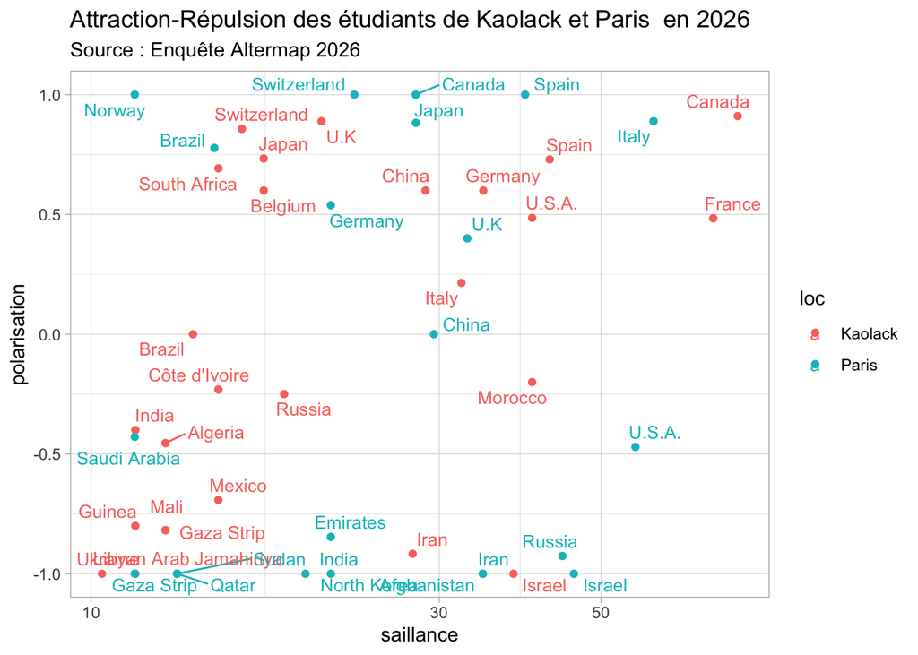

## B.3 Europe-Méditerranée-Afrique

Quels sont les mots associés par les étudiants de géographie à ces trois territoires qui forment une région verticale reliant pays du Nord et du Sud ?

### Quelles méthodes d’analyse ?

Sur le plan méthodologique, l’exploitation des résultats peut se faire selon au moins trois types de méthodes :

1. **Comptage des mots les plus fréquents et visualisation sous la forme de nuages de mots**. Cette technique rapide - mais imparfaite - est bien adaptée à une première exploration du corpus. Elle peut être facilement réalisée avec des outils en ligne comme [wordart](https://wordart.com)
2. **Analyse textuelle à l’aide d’outils de lemmatisation ou racinisation**. Cette technique plus exigeante implique l’emploi de logiciels spécialisés disponibles à travers des packages comme Iramuteq, Spacyr, Quanteda, Udpipe, … qui suppose une maîtrise des langages R ou Python. Ou bien d’interfaces en ligne, plus simples d’utilisation, mais qui implique en tout état de cause une formation aux concepts et méthodes de l’analyse textuelle.
3. **Codage manuel de catégories en fonction d’une problématique**. Cette méthode relève davantage des approches qualitatives utilisées par exemple dans les études du contenu des journaux. Pour être menée de façon rigoureuse, elle suppose l’établissement d’une grille de codage (e.g. on va chercher les mots relevant du thème de la violence) puis d’un test de comparaison des résultats de deux codeurs appliquant la grille afin de vérifier si leurs résultats sont convergents (test du Kappa de Cohen).

### Les mots de l’Europe

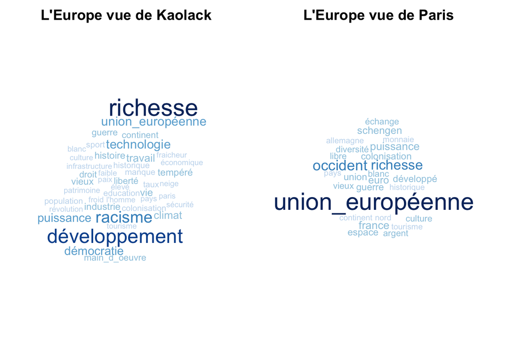

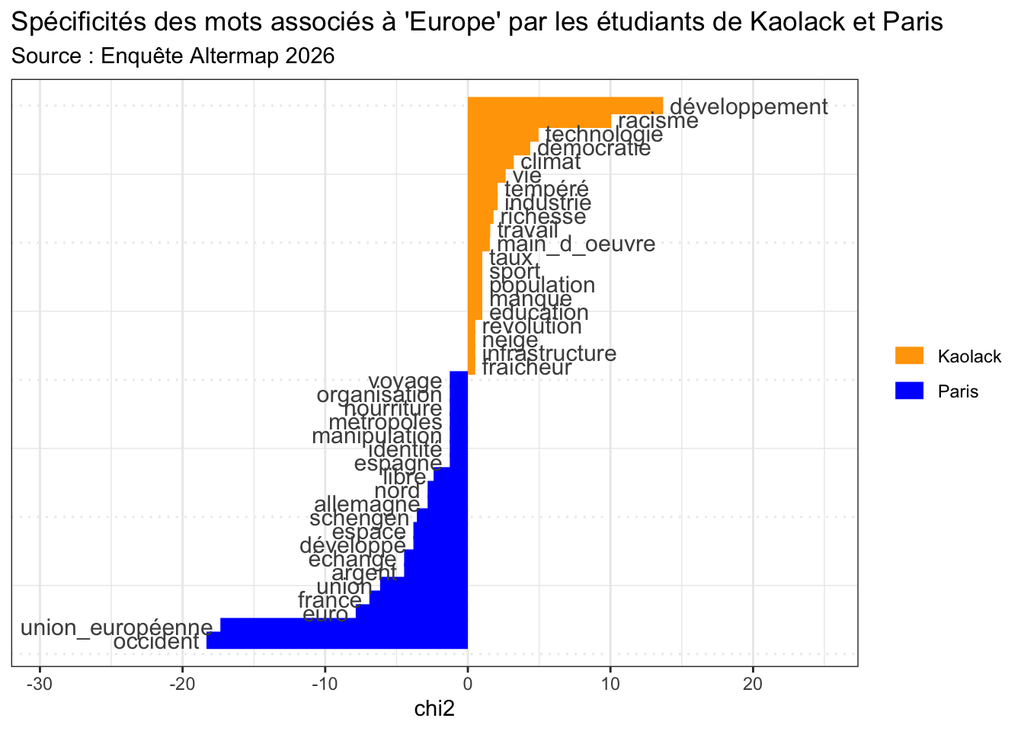

### Les mots de la Méditerranée

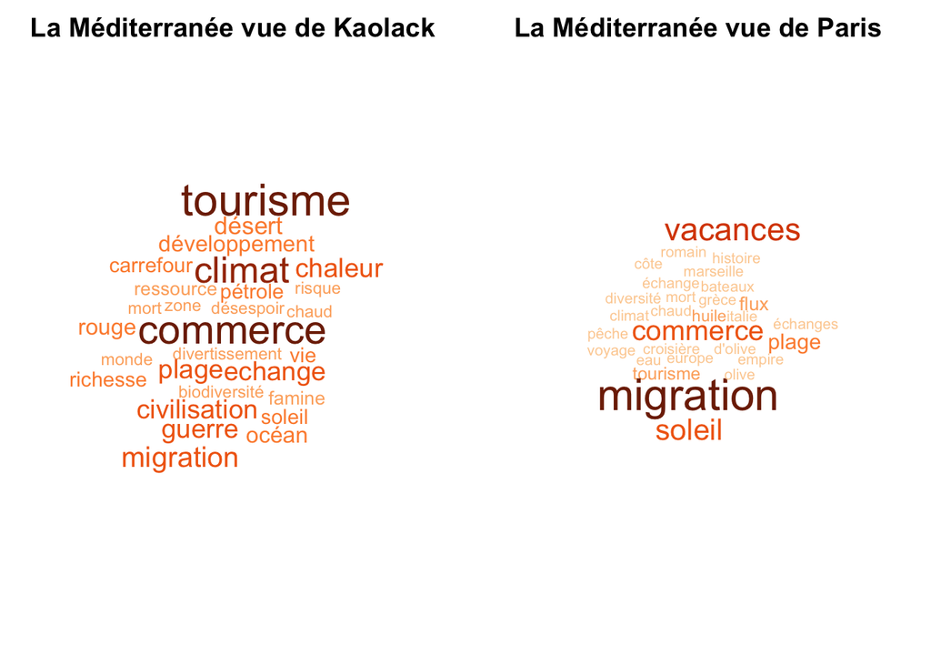

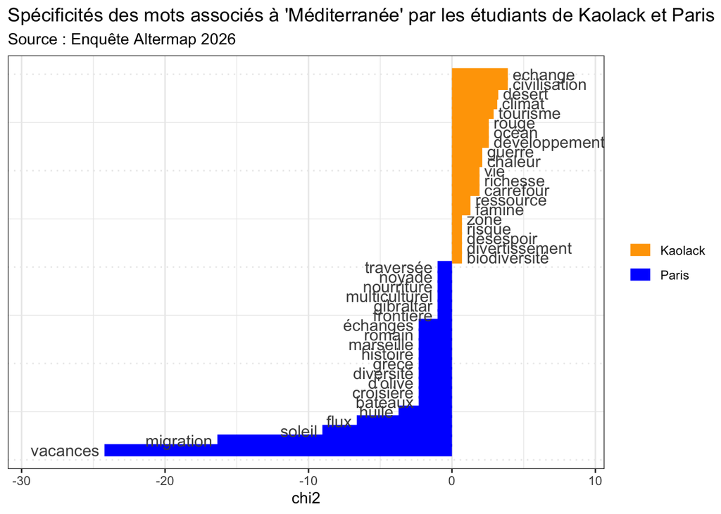

### Les mots de l’Afrique

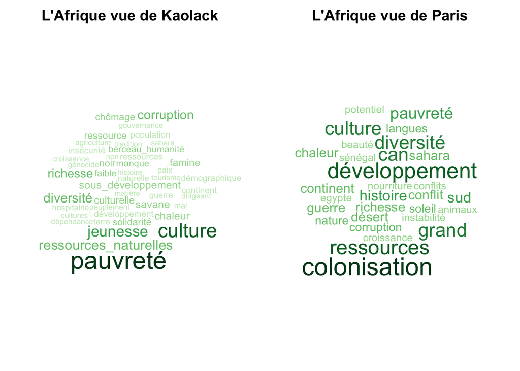

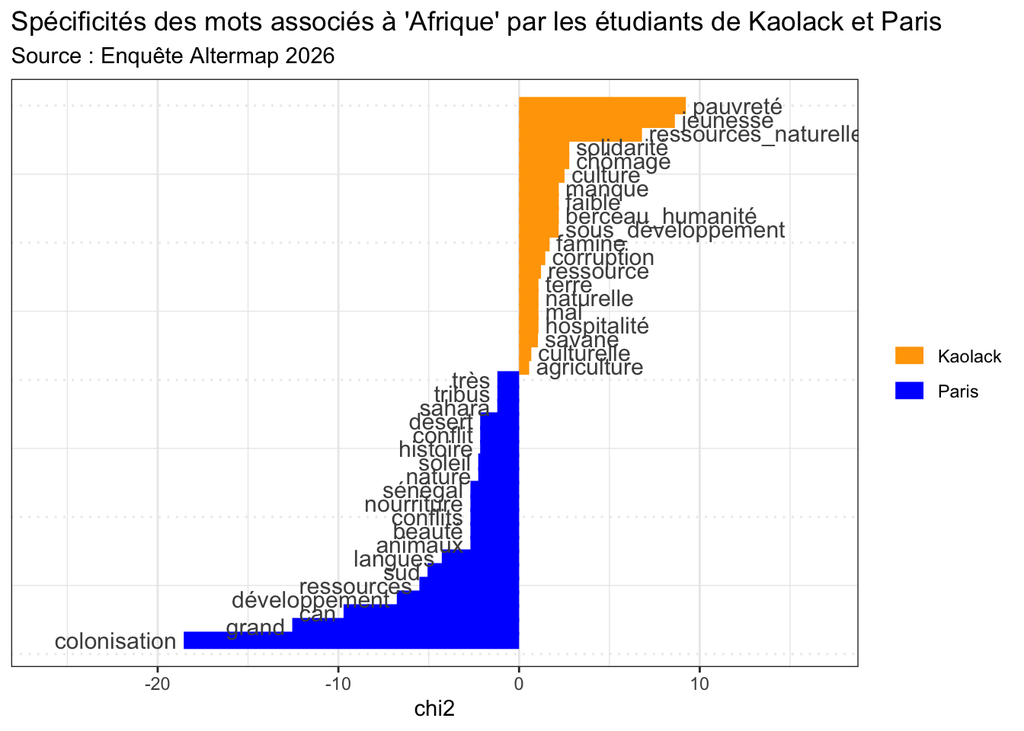